# Práctica 1: Polarización de la luz. Ley de Malus. Sacarimetría.

## 1. Conceptos previos

*En grupo, discute las siguientes cuestiones:*

- ¿Por qué no hablamos de polarización del sonido pero sí de polarización de la luz? ¿Qué entendemos por diferentes estados de polarización?
- ¿Qué es la polarización lineal? ¿Y la polarización circular?
- ¿Qué entendemos por luz natural? ¿Y luz parcialmente polarizada?
- ¿Qué hace un filtro polarizador?

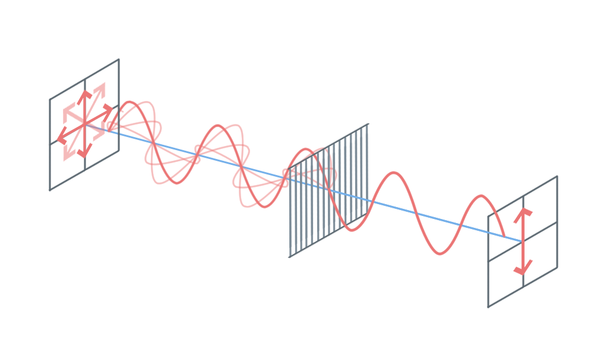

*Efecto de un filtro polarizador sobre la luz natural. Imagen tomada de https://theory.labster.com/es/polarization*

## 2. Objetivos de la práctica

- Estudio del funcionamiento de un polarizador.
- Verificación de la ley de Malus.
- Estudio de la acción de sustancias ópticamente activas sobre el estado de polarización de la luz.
- Observación del fenómeno de fotoelasticidad.

## 3. Fundamento teórico

### 3.1. Ley de Malus

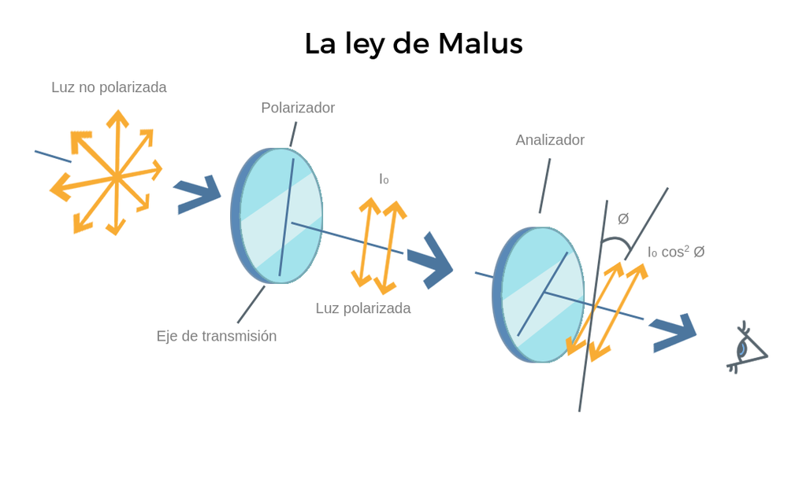

*Imagen tomada de https://theory.labster.com/es/malus-law*

### 3.2. Actividad óptica

Algunas disoluciones tienen la capacidad de rotar el plano de polarización de un haz linealmente polarizado. Este fenómeno se conoce como actividad óptica, y se rige por la ley de Biot: $$ \alpha = \Gamma l c,$$ donde $\alpha$ es el ángulo rotado, $l$ la distancia que recorre el haz en la disolución y $c$ la concentración de esta. $\Gamma$ es la *constante de rotación específica*, y depende de la disolución y la temperatura. También varía con la propia longitud de onda del haz, de forma que $\Gamma \lambda^2 = \mathrm{cte.}$ Para la longitud de onda del sodio ($\lambda_D = 589.3$ nm) y a una temperatura $20^\circ$, $\Gamma_D = +0.665^\circ\cdot\mathrm{L/m\cdot g}$.

[figure not shown]

[figure not shown]

Actividad óptica. Imagen tomada de https://www.chemistrysteps.com/optical-activity/

*Imagen tomada de https://www.chemistrysteps.com/optical-activity*

## 4. Materiales

*Identifica, en tu montaje, los siguientes elementos:*

- Láser de He-Ne.
- Dos filtros polarizadores con goniómetro.
- Fotómetro.
- Multímetro.
- Cubetas de vidrio de diferentes tamaños (al menos 3).
- Regla milimetrada.
- Plataforma de altura regulable.
- Azúcar (~50g) y vaso de precipitado.
- Báscula.
- Matraz aforado.

*Para la última parte ("fotoelasticidad") necesitas, además:*

- Dos polarizadores grandes.
- Una lámina de plástico tipo "pinza".
- Una regla de plástico o transportador de ángulos.

**PRECAUCIONES:**

- No mires directamente al láser.
- EXTREMA EL CUIDADO al manipular las cubetas de agua y el matraz.
- No excedas el peso máximo de la báscula.
- Al finalizar, limpia las cubetas con agua y jabón para eliminar cualquier resto de la disolución de azúcar.
- Deja limpia y ordenada la mesa de trabajo al finalizar.

## 5. Mediciones

### 5.1. Estado de polarización del láser

- Con un único polarizador, realiza varias medidas con las que puedas extraer alguna conclusión sobre el estado de polarización del láser.
- **NOTAS:**
  - ¿Se están midiendo intensidades lumínicas (en W/m²), o intensidades de corriente (en A)? ¿Es relevante esto?

### 5.2. Ley de Malus

- Fija la orientación del primer polarizador, y mide la intensidad EMERGENTE $I_0$. Seguidamente, variando la orientación del segundo polarizador, realiza diferentes medidas para comprobar experimentalmente la ley de Malus ($I_e \propto \cos^2\phi$).
- **NOTAS:**
  - La posición del eje del primer polarizador es relativamente arbitraria. ¿Conviene hacerlo para que pase una intensidad grande o una intensidad pequeña?
  - Decide qué medidas (directas o indirectas) vas a representar para llegar a un ajuste lineal. Discute el significado de la pendiente y la ordenada en el origen de tu ajuste. ¿Por qué $I_e\neq I_0$ cuando $\phi=0$?
  - Toma al menos 15 medidas para tu ajuste.

### 5.3. Sacarimetría

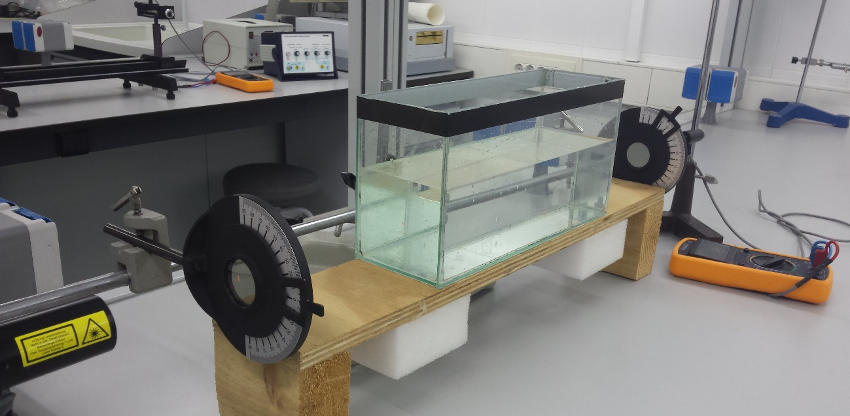

*Algunas partes del montaje pueden diferir del tuyo.*

1. Prepara una disolución de azúcar en agua de unos 50-70 g/L. Anota la concentración usada. Asegúrate de no saturar la disolución, y que toda el azúcar está disuelta. Verterás esta disolución de una cubeta a otra durante el experimento.
2. Coloca un polarizador delante del láser para asegurar que el haz esté linealmente polarizado en una dirección determinada.
3. Utiliza el segundo polarizador y el fotómetro como analizador del haz tras pasar por la disolución.
4. Diseña un experimento para comprobar la ley de Biot, esto es, que el ángulo rotado es proporcional a la distancia recorrida ($\alpha\propto l$). Utiliza 3 cubetas de diferente longitud (ancho y largo), es decir, 6 medidas.
5. A partir del ajuste lineal, determina la concentración, y compara con el valor anotado previamente.
- **NOTAS:**
  - A la hora de usar el segundo polarizador (analizador), puedes trabajar en intensidad máxima, o bien en intensidad mínima (y luego rotar $90^\circ$ para determinar el estado de polarización). Este último método, a pesar de involucrar un paso más, tiene una ventaja. Discute cuál.
  - Para determinar la concentración, necesitas conocer la longitud de onda a la que opera un láser de He-Ne. Recuerda que para la longitud de onda del sodio, $\lambda_D = 589.3$ nm, la constante de rotación específica de una disolución de azúcar es $\Gamma_D = +0.665^\circ\cdot\mathrm{L/m\cdot g}$.

### 5.4. Fotoelasticidad

En este apartado vas a observar y discutir el fenómeno de fotoelasticidad de forma cualitativa, sin necesidad de realizar ninguna medición:

1. Coloca los dos polarizadores grandes en posición cruzada (ejes de transmisión a 90º).
2. Sitúa la lámina de plástico transparente (tipo "pinza") entre los polarizadores.
3. Con una luz natural de fondo, tensiona la lámina con la mano y observa el fenómeno.
4. Repite la observación con una regla de plástico o un transportador de ángulos (no es necesario aplicar tensión aquí).

Discute el fenómeno observado, investigando en la literatura sobre la fotoelasticidad y relacionándolo con otros fenómenos como la actividad óptica.

**RECUERDA**

- No mires directamente al láser.
- EXTREMA EL CUIDADO al manipular las cubetas de agua y el matraz.
- No excedas el peso máximo de la báscula.
- Al finalizar, limpia las cubetas con agua y jabón para eliminar cualquier resto de la disolución de azúcar.
- Deja limpia y ordenada la mesa de trabajo al finalizar.